# DATA 605: Computational Mathematics

Gabriel Campos

Last edited December 12, 2024

# Library

```r
library(corrplot)
library(dplyr)
library(e1071)
library(ggcorrplot)
library(ggplot2)
library(Hmisc)
library(kableExtra)
library(MASS)
library(Matrix)
library(matrixcalc)
library(readr)
```

**Final Examination: Business Analytics and Data Science**

# Instructions:

You are required to complete this take-home final examination by the end of the last week of class. Your solutions should be uploaded in **pdf** format as a knitted document (with graphs, content, commentary, etc. in the pdf). This project will showcase your ability to apply the concepts learned throughout the course.

The dataset you will use for this examination is provided as [retail data.csv](https://brightspace.cuny.edu/content/enforced/437177-SPS01_DATA_605_1249_15536/synthetic_retail_data.csv), which contains the following variables:

- Product_ID: Unique identifier for each product.
- Sales: Simulated sales numbers (in dollars).
- Inventory_Levels: Inventory levels for each product.
- Lead_Time_Days: The lead time in days for each product.
- Price: The price of each product.
- Seasonality_Index: An index representing seasonality.

# Problem 1:

**Business Risk and Revenue Modeling**

**Context:** You are a data scientist working for a retail chain that models sales, inventory levels, and the impact of pricing and seasonality on revenue. Your task is to analyze various distributions that can describe sales variability and forecast potential revenue.

## Data Load

```r
retail_df <- read_csv("synthetic_retail_data.csv")
```

### Part 1:

**Empirical and Theoretical Analysis of Distributions (5 Points)**

**Task:**

### 1.

**Generate and Analyze Distributions:**

- **X ~ Sales:** Consider the Sales variable from the dataset. Assume it follows a Gamma distribution and estimate its shape and scale parameters using the fitdistr function from the MASS package.
- **Y ~ Inventory Levels:** Assume that the sum of inventory levels across similar products follows a Lognormal distribution. Estimate the parameters for this distribution.
- **Z ~ Lead Time:** Assume that Lead_Time_Days follows a Normal distribution. Estimate the mean and standard deviation. Calculate Empirical Expected Value and Variance:

```r
head(retail_df)
```

| Product_ID | Sales | Inventory_Levels | Lead_Time_Days | Price | Seasonality_Index |
| --- | --- | --- | --- | --- | --- |
| 1 | 158.4395 | 367.4421 | 6.314587 | 18.79520 | 1.1839497 |
| 2 | 278.9902 | 426.6512 | 5.800673 | 26.08964 | 0.8573051 |
| 3 | 698.8587 | 407.6394 | 3.071936 | 22.39998 | 0.6986774 |
| 4 | 1832.3947 | 392.3912 | 3.534253 | 27.09201 | 0.6975404 |
| 5 | 459.7039 | 448.3120 | 10.802241 | 18.30782 | 0.8407251 |
| 6 | 1692.5191 | 547.4102 | 10.147199 | 23.48068 | 1.1319305 |

```r
glimpse(retail_df)
```

```
Rows: 200
Columns: 6
$ Product_ID        <dbl> 1, 2, 3, 4, 5, 6, 7, 8, 9, 10, 11, 12, 13, 14, 15, 1…
$ Sales             <dbl> 158.43952, 278.99020, 698.85868, 1832.39467, 459.703…
$ Inventory_Levels  <dbl> 367.4421, 426.6512, 407.6394, 392.3912, 448.3120, 54…
$ Lead_Time_Days    <dbl> 6.314587, 5.800673, 3.071936, 3.534253, 10.802241, 1…
$ Price             <dbl> 18.795197, 26.089636, 22.399985, 27.092013, 18.30782…
$ Seasonality_Index <dbl> 1.1839497, 0.8573051, 0.6986774, 0.6975404, 0.840725…
```

```r
summary(retail_df)
```

```
   Product_ID         Sales         Inventory_Levels Lead_Time_Days
 Min.   :  1.00   Min.   :  25.57   Min.   : 67.35   Min.   : 0.491
 1st Qu.: 50.75   1st Qu.: 284.42   1st Qu.:376.51   1st Qu.: 5.291
 Median :100.50   Median : 533.54   Median :483.72   Median : 6.765
 Mean   :100.50   Mean   : 636.92   Mean   :488.55   Mean   : 6.834
 3rd Qu.:150.25   3rd Qu.: 867.58   3rd Qu.:600.42   3rd Qu.: 8.212
 Max.   :200.00   Max.   :2447.49   Max.   :858.79   Max.   :12.722
     Price        Seasonality_Index
 Min.   : 5.053   Min.   :0.3305
 1st Qu.:16.554   1st Qu.:0.8475
 Median :19.977   Median :0.9762
 Mean   :19.560   Mean   :0.9829
 3rd Qu.:22.924   3rd Qu.:1.1205
 Max.   :29.404   Max.   :1.5958
```

#### X ~ Sales

**X ~ Sales:** Consider the Sales variable from the dataset. Assume it follows a Gamma distribution and estimate its shape and scale parameters using the fitdistr function from the MASS package.

```r
# Isolate Sales data
sales_retail_df <- retail_df$Sales
summary(sales_retail_df)
```

```
   Min. 1st Qu.  Median    Mean 3rd Qu.    Max.
  25.57  284.42  533.54  636.92  867.58 2447.49
```

```r
sum(sales_retail_df<0)
```

```
[1] 0
```

```r
sum(is.na(sales_retail_df))
```

```
[1] 0
```

```r
shapiro.test(sales_retail_df)
```

```
    Shapiro-Wilk normality test

data:  sales_retail_df
W = 0.90377, p-value = 4.397e-10
```

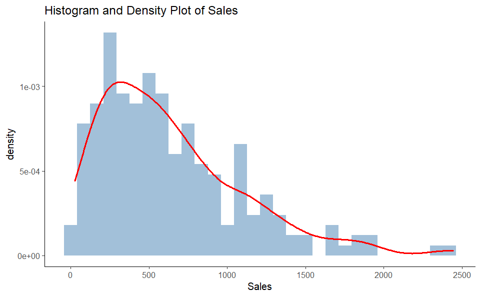

```r
ggplot(retail_df, aes(x = Sales)) +
  geom_histogram(aes(y = ..density..),
                 bins = 30, fill = "steelblue",
                 alpha = 0.5) +
  geom_density(color = "red", size = 1) +
  ggtitle("Histogram and Density Plot of Sales") +
  theme_classic()
```

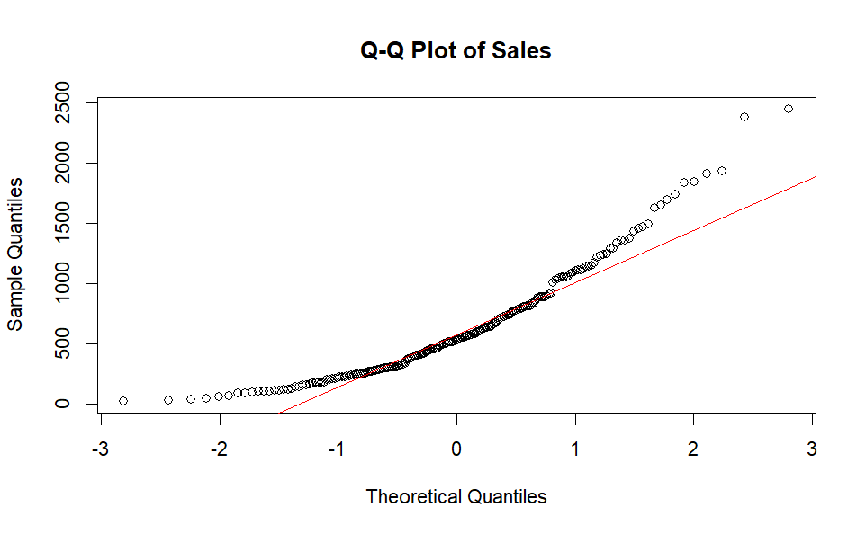

```r
qqnorm(sales_retail_df,
       main = "Q-Q Plot of Sales")
qqline(sales_retail_df,
       col = "red")
```

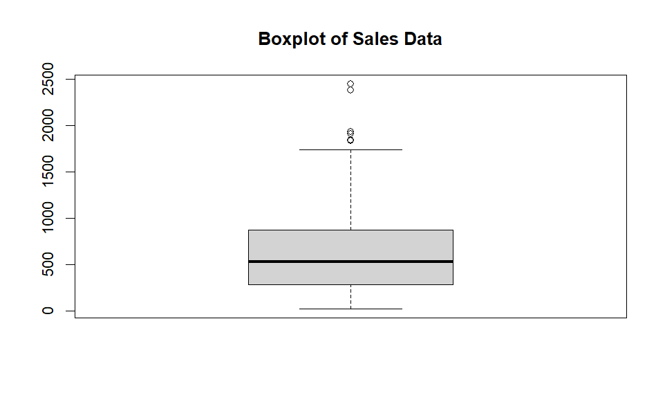

```r
boxplot(sales_retail_df,
        main = "Boxplot of Sales Data")
```

##### fitdstr Sales Solution

Assume $X \sim Gamma(\alpha, \beta)$ the parameter *“gamma”* will be used with *fitdistr()*.

```r
sales_gamma_fit <- fitdistr(sales_retail_df, "gamma")
```

```
Warning: NaNs produced
```

```r
print(sales_gamma_fit)
```

```
      shape           rate
  1.8349640762   0.0028810166
 (0.1511756159) (0.0002556985)
```

Considering no NAs or negative values were noted in our original data set, the $NaNs \ produced$ warning, is likely a result of the right-skewed data or from our outliers. I will remove the outliers to see if it removes the warning. Regardless, dealing with these outliers should improve precision.

The below steps should remove values above our 99% quantile or below the 1%

```r
# compute quantiles at 1% and and 99%
sales_retail_quantiles <-
  quantile(sales_retail_df, probs =c(0.01,0.99))
# remove outliers below the 1% and above 99%
sales_retail_df_clean<- sales_retail_df[
  sales_retail_df >= sales_retail_quantiles[1] &
    sales_retail_df <= sales_retail_quantiles[2]
]
sales_gamma_fit_clean <- fitdistr(sales_retail_df_clean, "gamma")
print(sales_gamma_fit_clean)
```

```
      shape           rate
  2.0323543224   0.0032518379
 (0.1724396139) (0.0002975715)
```

```r
hist(sales_retail_df_clean,
     breaks = 30,
     probability = TRUE,
     main = "Fitted Gamma Distribution",
     xlab = "Sales",
     col = "steelblue")

curve(dgamma(x,
             shape = 1.8349640762,
             rate = 0.0028810166),
      col = "red",
      lwd = 2,
      add = TRUE)
```

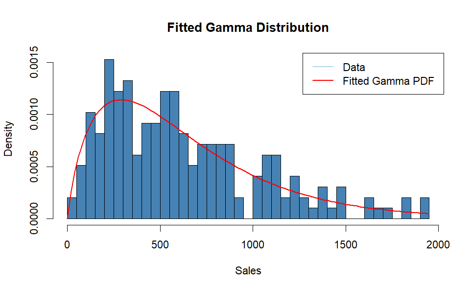

```r
legend("topright",
       legend = c("Data",
                  "Fitted Gamma PDF"),
       col = c("lightblue",
               "red"), lwd = 2)
```

```r
hist(sales_retail_df,
     breaks = 30,
     probability = TRUE,
     main = "Fitted Gamma Distribution",
     xlab = "Sales",
     col = "royalblue")

curve(dgamma(x,
             shape = 2.0323543224,
             rate = 0.0032518379 ),
      col = "red",
      lwd = 2,
      add = TRUE)
```

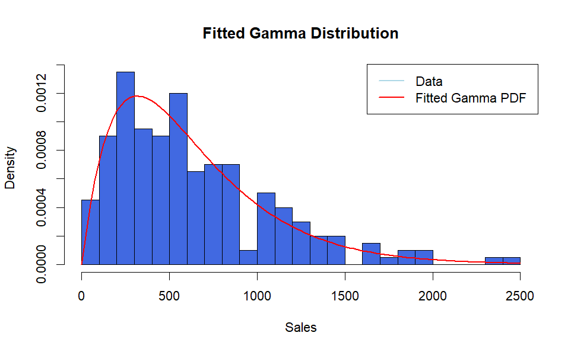

```r
legend("topright",
       legend = c("Data",
                  "Fitted Gamma PDF"),
       col = c("lightblue",
               "red"), lwd = 2)
```

Visually, both values seem to match the $Sales$ behavior. By calculating the absolute difference in mean, skewness and variance, I might get a better indication on which gamma distribution and gamma parameters, better emulates the datas behavior.

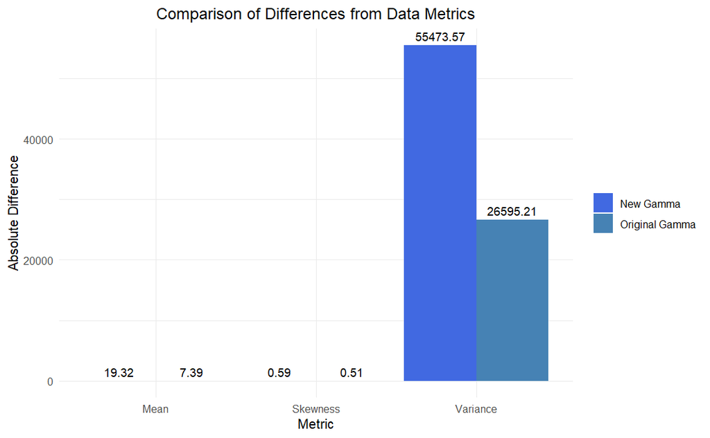

```r
cmp_metrics <- c("Mean", "Variance", "Skewness")

cmp_data_values <- c(617.595, 165599.6, 0.8891198)

# Original Gamma differences
cmp_shape1 <- 2.0323543224

cmp_rate1 <- 0.0032518379

cmp_original_gamma_values <-
  c(cmp_shape1 / cmp_rate1,
    cmp_shape1 / (cmp_rate1^2),
    2 / sqrt(cmp_shape1))

cmp_original_differences <-
  abs(cmp_original_gamma_values - cmp_data_values)

# New Gamma differences
cmp_shape2 <- 1.8349640762
cmp_rate2 <- 0.0028810166

cmp_new_gamma_values <-
  c(cmp_shape2 / cmp_rate2,
    cmp_shape2 / (cmp_rate2^2),
    2 / sqrt(cmp_shape2))
cmp_new_differences <-
  abs(cmp_new_gamma_values - cmp_data_values)

# Prepare data for ggplot
plot_data <- data.frame(
  Metric = rep(cmp_metrics,
               times = 2),
  Difference =
    c(cmp_original_differences,
                 cmp_new_differences),
  Gamma = rep(c("Original Gamma",
                "New Gamma"),
              each = length(cmp_metrics))
)

# Create the clustered bar plot
ggplot(plot_data, aes(x = Metric, y = Difference, fill = Gamma)) +
  geom_bar(stat = "identity", position = position_dodge(width = 0.9)) +
  geom_text(aes(label = round(Difference, 2)),
            position = position_dodge(width = 0.9),
            vjust = -0.5, size = 3.5) +
  labs(
    title = "Comparison of Differences from Data Metrics",
    x = "Metric",
    y = "Absolute Difference"
  ) +
  scale_fill_manual(values = c("Original Gamma" = "steelblue", "New Gamma" = "royalblue")) +
  theme_minimal() +
  theme(
    plot.title = element_text(hjust = 0.5),
    legend.title = element_blank()
  )
```

##### Mean and Variance (X~Sales) Solution

Our Empirical mean and variance is just

```r
sales_empirical_mean<-mean(sales_retail_df)
sales_empirical_var<-var(sales_retail_df)
```

and our theoretical mean and variance is calculate as

$\mu_{gamma}=\frac{\alpha}{\beta}$

$\sigma^2_{gamma}=\frac{\alpha}{\beta^2}$ or $\frac{shape}{rate^2}$

```r
sales_gamma_shape <- sales_gamma_fit$estimate["shape"]
sales_gamma_rate <- sales_gamma_fit$estimate["rate"]

sales_theoretical_gamma_mean <- sales_gamma_shape / sales_gamma_rate
sales_theoretical_gamma_var <- sales_gamma_shape/ (sales_gamma_rate^2)
```

```r
comparison_Sales <- data.frame(
  Metric = c("Mean", "Variance"),
  Empirical = c(sales_empirical_mean, sales_empirical_var),
  Theoretical = c(sales_theoretical_gamma_mean, sales_theoretical_gamma_var)
)
```

#### Y ~ Inventory Levels

**Y ~ Inventory Levels:** Assume that the sum of inventory levels across similar products follows a Lognormal distribution. Estimate the parameters for this distribution.

```r
inv_retail_df <- retail_df$Inventory_Levels
summary(inv_retail_df)
```

```
   Min. 1st Qu.  Median    Mean 3rd Qu.    Max.
  67.35  376.51  483.72  488.55  600.42  858.79
```

```r
sum(inv_retail_df<0)
```

```
[1] 0
```

```r
sum(is.na(inv_retail_df))
```

```
[1] 0
```

```r
shapiro.test(inv_retail_df)
```

```
    Shapiro-Wilk normality test

data:  inv_retail_df
W = 0.99303, p-value = 0.4646
```

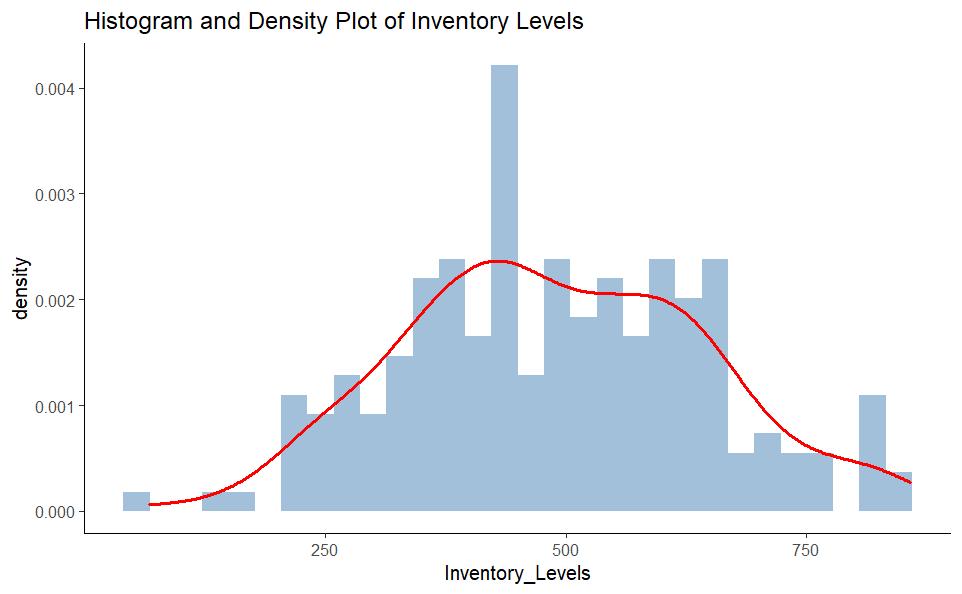

```r
ggplot(retail_df, aes(x = Inventory_Levels )) +
  geom_histogram(aes(y = ..density..),
                 bins = 30, fill = "steelblue",
                 alpha = 0.5) +
  geom_density(color = "red", size = 1) +
  ggtitle("Histogram and Density Plot of Inventory Levels") +
  theme_classic()
```

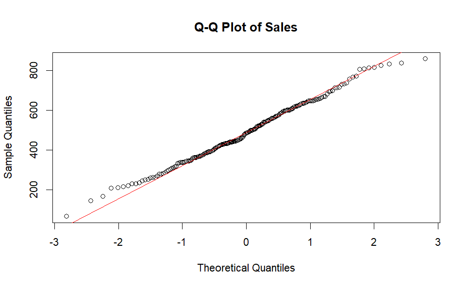

```r
qqnorm(inv_retail_df,
       main = "Q-Q Plot of Sales")
qqline(inv_retail_df,
       col = "red")
```

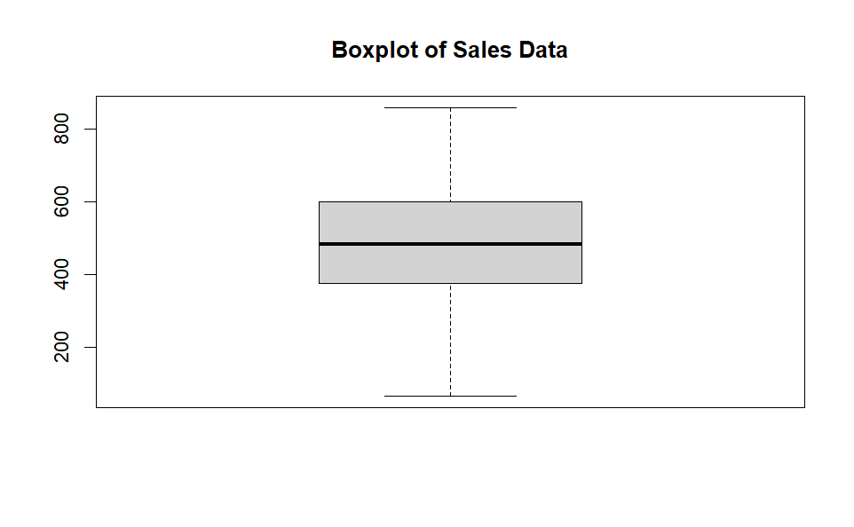

```r
boxplot(inv_retail_df,
        main = "Boxplot of Sales Data")
```

##### fitdistr Inventory Levels

Since we are assuming the Inventory Levels across products follows a Lognormal distribution $(Y \sim Lognormal(\mu,\sigma^2))$, the parameter for *fitdistr()* we use is *lognormal*. Since we are explicitly looking for the sum of inventory levels across similar products, we will *sum* can consider finding the values for the individual *Product_ID*’s before evaluating the distribution.

```r
retail_df %>%
  group_by(Inventory_Levels) %>%
  summarise(Count = n()) %>%
  filter(Count > 1)
```

| Inventory_Levels | Count |
| --- | --- |

Since it appears that all *Product_ID*’s are unique I will refrain from using the sum.

The parameters of this distribution will ultimately be $\mu_{log}$ and $\sigma_{log}$

```r
inv_lognormal <-
  fitdistr(inv_retail_df,"lognormal")

inv_log_mean <- inv_lognormal$estimate["meanlog"]
inv_log_var <- inv_lognormal$estimate["sdlog"]

print(inv_lognormal)
```

```
    meanlog       sdlog
  6.13303680   0.36332727
 (0.02569112) (0.01816636)
```

```r
# Histogram for Inventory Levels
hist(inv_retail_df,
     breaks = 30,
     probability = TRUE,
     main = "Fitted Lognormal Distribution",
     xlab = "Inventory Levels",
     col = "slateblue")

# Overlay the fitted lognormal curve
curve(dlnorm(x,
             meanlog = inv_log_mean,
             sdlog = inv_log_var),
      col = "red",
      lwd = 2,
      add = TRUE)
```

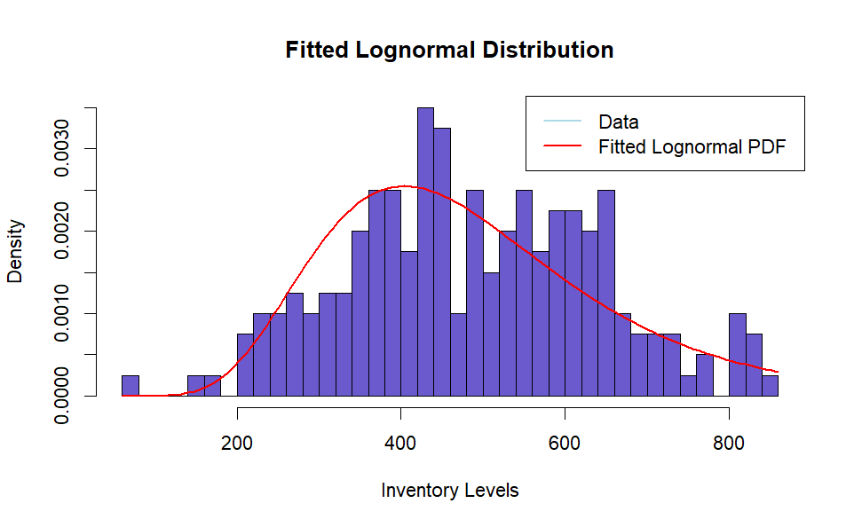

```r
# Add legend
legend("topright",
       legend = c("Data", "Fitted Lognormal PDF"),
       col = c("lightblue", "red"),
       lwd = 2)
```

##### Mean and Variance (Y~Inventory Levels)

*Theoretical Mean* or $E[x]$ of a random variable $X \sim Lognormal(\mu,\sigma^2)$ is equal to $e^{\mu+\frac{\sigma^2}{2}}$ and its theoretical variance is $(e^{\sigma^2}-1) e^{2\mu+\sigma^2}$

```r
# Empirical statistics
inv_empirical_mean <- mean(retail_df$Inventory_Levels)
inv_empirical_variance <- var(retail_df$Inventory_Levels)

# Theoretical mean and variance for lognormal distribution
inv_theoretical_mean <-
  exp(inv_log_mean +
        (inv_log_var^2) / 2)

inv_theoretical_variance <-
  (exp(inv_log_var^2) - 1) *
  exp(2 * inv_log_mean + inv_log_var^2)

# # Print results
# cat("Empirical Mean:", empirical_mean, "\n")
# cat("Theoretical Mean:", theoretical_mean, "\n")
# cat("Empirical Variance:", empirical_variance, "\n")
# cat("Theoretical Variance:", theoretical_variance, "\n")

comparison_Inventory_Level <- data.frame(
  Metric = c("Mean", "Variance"),
  Empirical = c(inv_empirical_mean, inv_empirical_variance),
  Theoretical = c(inv_theoretical_mean, inv_theoretical_variance)
)
```

#### Z ~ Lead Time

**Z ~ Lead Time:** Assume that Lead_Time_Days follows a Normal distribution. Estimate the mean and standard deviation.

Calculate Empirical Expected Value and Variance:

```r
ltd_retail_df <- retail_df$Lead_Time_Days
summary(ltd_retail_df)
```

```
   Min. 1st Qu.  Median    Mean 3rd Qu.    Max.
  0.491   5.291   6.765   6.834   8.212  12.722
```

```r
sum(ltd_retail_df<0)
```

```
[1] 0
```

```r
sum(is.na(ltd_retail_df))
```

```
[1] 0
```

```r
shapiro.test(ltd_retail_df)
```

```
    Shapiro-Wilk normality test

data:  ltd_retail_df
W = 0.99618, p-value = 0.9026
```

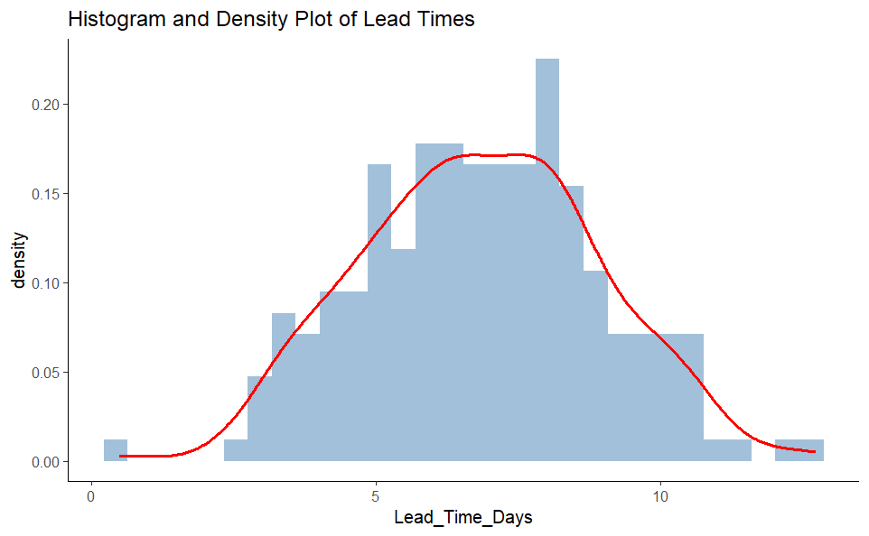

```r
ggplot(retail_df, aes(x = Lead_Time_Days )) +
  geom_histogram(aes(y = ..density..),
                 bins = 30, fill = "steelblue",
                 alpha = 0.5) +
  geom_density(color = "red", size = 1) +
  ggtitle("Histogram and Density Plot of Lead Times") +
  theme_classic()
```

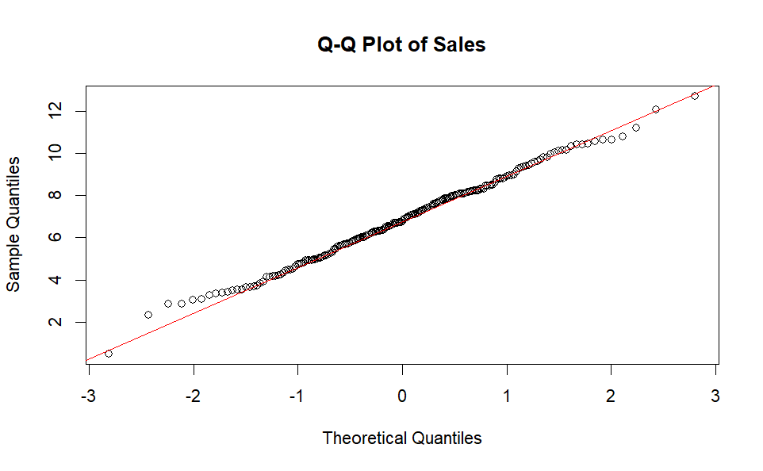

```r
qqnorm(ltd_retail_df,
       main = "Q-Q Plot of Sales")
qqline(ltd_retail_df,
       col = "red")
```

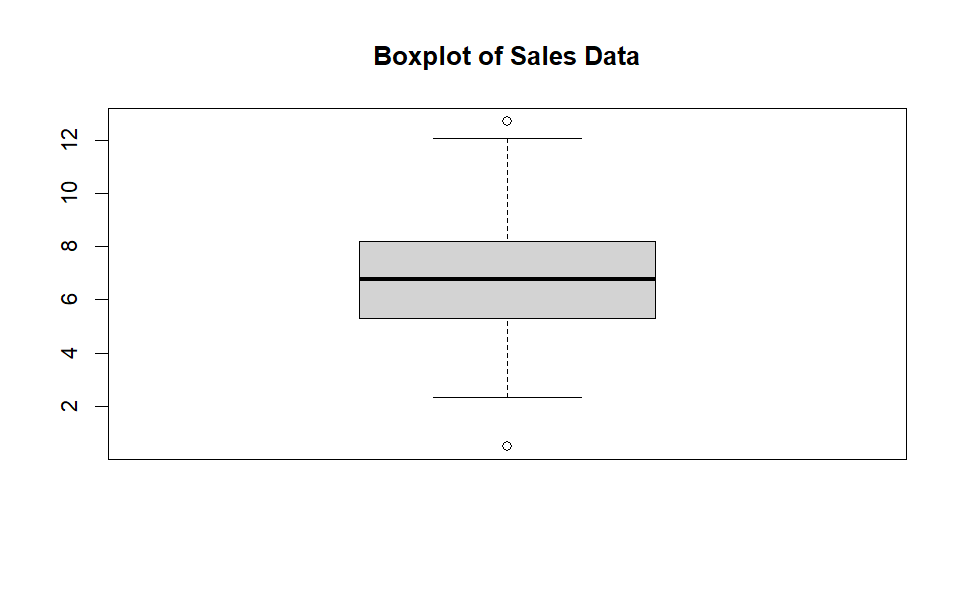

```r
boxplot(ltd_retail_df,
        main = "Boxplot of Sales Data")
```

This data is basically normalized, with a slight right skewed and outliers that do not deviate much from the mean.

##### Mean and Variance Lead Time Solution

We are using the same data with our theoretical Mean and Variance. Considering this, finding the mean and variance for our Lead Times should be the same. Another way of deriving our varian would be to square our standard deviation or $\sigma$. I’ve applied a few methods to show this.

1. Finding the standard deviation and squaring it
2. Using the *var()* function directly
3. Using the *fitdistr()* function to conclude our mean and standard are the same (alternatively I called on the *estimate* attribute for my *fitdistr* which is a redundant call to this value)

```r
ltd_empirical_mean <- mean(retail_df$Lead_Time_Days)
sd(retail_df$Lead_Time_Days)
```

```
[1] 2.088441
```

```r
sd(retail_df$Lead_Time_Days)^2
```

```
[1] 4.361587
```

```r
var(retail_df$Lead_Time_Days)
```

```
[1] 4.361587
```

```r
ltd_fitdistr<-fitdistr(ltd_retail_df,"normal")
print(ltd_fitdistr)
```

```
     mean         sd
  6.8342981   2.0832137
 (0.1473055) (0.1041607)
```

```r
ltd_fitdistr$estimate
```

```
    mean       sd
6.834298 2.083214
```

##### Answer

The estimated mean is $6.834298$ and standard deviation is $2.083214$ Calculated Empirical Expected Value is $6.834298$ and Variance is $4.361587$

## 2.

Calculate the empirical mean and variance for all three variables. Compare these empirical values with the theoretical values derived from the estimated distribution parameters.

### Answer

For **Y~Inventory**

```r
print(comparison_Inventory_Level)
```

[output not shown]

# Part 2:

**Probability Analysis and Independence Testing (5 Points)**

**Task:**

## 1.

**Empirical Probabilities:** For the Lead_Time_Days variable (assumed to be normally distributed), calculate the following empirical probabilities:

- $P(Z> \mu | Z > \mu - \sigma)$
- $P(Z> \mu + \sigma | Z > \mu)$
- $P(Z> \mu + 2\sigma | Z > \mu)$

**Notes**

- We assume the **standard normal distribution in context to these probabilities, because they do not specify a random variable $X$ with its own mean $\mu$ and standard deviation $\sigma$
- The standard normal distribution also known as the z distribution, can have the notation $N(\mu, \sigma)$ where N signifies the distribution is normal, while $\mu$, $\sigma$ and $\sigma^2$ retains its known definition as the mean, standard deviation and variance of the distribution. Please note **Reference** *vii* for a more in depth explanation.

### i.

- $P(Z> \mu | Z > \mu - \sigma)$ = $\frac{P(Z>\mu\ \cap \ Z>\mu-\sigma)}{Z>\mu-\sigma}$
- Our numerator can be simplified to $P(Z>\mu)$. Stated plainly, $P(Z>\mu-\sigma)$ is encompassed with $P(Z>\mu)$, but both conditions cannot be met if we only satisfy $P(Z>\mu-\sigma)$ therefore we only need to satisfy the second condition $P(Z > \mu)$.
- This simplifies our conditional probability $P(Z> \mu | Z > \mu - \sigma)$ = $\frac{P(Z>\mu\ \cap \ Z>\mu-\sigma)}{Z>\mu-\sigma}$ to $\frac{Z>\mu}{Z>\mu-\sigma}$
- $N(\mu, \sigma)$ for the standard normal distribution is $Z' \sim N(0,1)$, since the mean of a standard normal distribution is $\mu=0$ with a standard deviation of $\sigma=1$ (Reference *vii*).
- $P(Z>\mu)$ represents 50% of the probability as it is the mean $\therefore \ P(Z>\mu)=0.5$
- We can use the standardization formula $F_X(x) = P(X \leq x)=F_z(\frac{x- \mu}{\sigma})$ or just $Z=\frac{x- \mu}{\sigma}$ to substitute based on our second conditions probability (Grinstead and Snell’s Introduction to Probability pg. 214):
  - random variable $X=\mu-\sigma$
  - $X \sim N(\mu,\sigma^2) \rightarrow Z=\frac{(\mu-\sigma)-\mu}{\sigma} = -\frac{\sigma}{\sigma}=-1$
  - This transforms our formula from $Z>\mu-\sigma$ to $Z>-1$

we can find use *pnorm()* to get the value for $Z=-1$

```r
pnorm(-1)
```

```
[1] 0.1586553
```

Since $P(Z>-1)=1-P(Z \leq -1)$ we can solve by subtracting these values.

```r
1-pnorm(-1)
```

```
[1] 0.8413447
```

Again we are trying to solve for $\frac{Z>\mu}{Z>\mu-\sigma}$ and by substituting we get $\frac{0.5}{0.8413447}$ which is

**Conclusion**

```r
0.5/(1-pnorm(-1))
```

```
[1] 0.5942867
```

### ii.

- For $P(Z> \mu + \sigma | Z > \mu)$ we can use a similar conditional probability as above ($P(A|B)=\frac{P(A \cap B)}{P(B)}$) to get $\frac{P((Z > \mu + \sigma) \ \cap \ (Z>\mu))}{P(Z>\mu)}$
- In this probability the $P(Z > \mu + \sigma)$ the condition encompasses $P(Z>\mu)$, since for $P((Z > \mu + \sigma) \ \cap \ (Z>\mu)$ to be true, $P(Z > \mu + \sigma)$ would be required.
- Therefore $\frac{P((Z > \mu + \sigma) \ \cap \ (Z>\mu))}{P(Z>\mu)}$ can be written as $\frac{P(Z > \mu + \sigma)}{P(Z>\mu)}$
- $P(Z>\mu)=0.5$ as per our last probabilities conclusions.
- Again we can use the standardization formula $F_X(x) = P(X \leq x)=F_z(\frac{x- \mu}{\sigma})$ or just $Z=\frac{x- \mu}{\sigma}$ to substitute based on our second conditions probability (Grinstead and Snell’s Introduction to Probability pg. 214):
- random variable $X=\mu+\sigma$
  - $X \sim N(\mu,\sigma^2) \rightarrow Z=\frac{(\mu+\sigma)-\mu}{\sigma} = \frac{\sigma}{\sigma}=1$
  - This transforms our formula from $Z>\mu+\sigma$ to $Z>1$

Again we solve for $Z=1$ this using *pnorm()* and we understand $P(Z>1)=1-P(Z<1)$ because we are computing for the tail of this probability

```r
1-pnorm(1)
```

```
[1] 0.1586553
```

Which we will use substitute and solve for $\frac{P(Z > \mu + \sigma)}{P(Z>\mu)}$

**Conclusion**

```r
(1-pnorm(1))/0.5
```

```
[1] 0.3173105
```

### iii.

$P(Z> \mu + 2\sigma | Z > \mu)=\frac{P(Z>\mu + 2 \sigma \ \cap \ Z>\mu)}{Z>\mu}$ where $P(Z>\mu + 2 \sigma \ \cap \ Z>\mu)$ implies $Z>\mu + 2 \sigma$ for our numerator and $Z>\mu=0.5$ based on previous work. - Substituting for the standardization formula we get $X \sim N(\mu,\sigma^2) \rightarrow Z=\frac{(\mu+2\sigma)-\mu}{\sigma} = \frac{2\sigma}{\sigma}=2$ - $P(Z>2)=1-P(Z<2)=\frac{1-P(Z<2)}{0.5}$ which is

**Conclusion**

```r
(1-pnorm(2))/0.5
```

```
[1] 0.04550026
```

### Answers

- $P(Z> \mu | Z > \mu - \sigma) \approx 0.594$
- $P(Z> \mu + \sigma | Z > \mu) \approx 0.317$
- $P(Z> \mu + 2\sigma | Z > \mu) \approx 0.0455$

## 2.

**Correlation and Independence:**

- Investigate the correlation between Sales and Price. Create a contingency table using quartiles of Sales and Price, and then evaluate the marginal and joint probabilities.
- Use Fisher’s Exact Test and the Chi-Square Test to check for independence between Sales and Price. Discuss which test is most appropriate and why.

### Contingency, Joint and Marginal Table

**Contingency**

```r
sales_qrtl <- cut(retail_df$Sales,
                        breaks = quantile(retail_df$Sales,
                                          probs = seq(0, 1, 0.25)),
                        include.lowest = TRUE,
                        labels = c("Q1", "Q2", "Q3", "Q4"))


price_qrtl <- cut(retail_df$Price,
                        breaks = quantile(retail_df$Price,
                                          probs = seq(0, 1, 0.25)),
                        include.lowest = TRUE,
                        labels = c("Q1", "Q2", "Q3", "Q4"))
cont_tbl <- table(sales_qrtl, price_qrtl)

cont_tbl %>%
    kable()
```

|  | Q1 | Q2 | Q3 | Q4 |
| --- | --- | --- | --- | --- |
| Q1 | 11 | 16 | 12 | 11 |
| Q2 | 13 | 10 | 15 | 12 |
| Q3 | 15 | 10 | 13 | 12 |
| Q4 | 11 | 14 | 10 | 15 |

```r
jnt_tbl<-prop.table(cont_tbl)

jnt_tbl %>%
  kable() %>%
  kable_paper()
```

|  | Q1 | Q2 | Q3 | Q4 |
| --- | --- | --- | --- | --- |
| Q1 | 0.055 | 0.08 | 0.060 | 0.055 |
| Q2 | 0.065 | 0.05 | 0.075 | 0.060 |
| Q3 | 0.075 | 0.05 | 0.065 | 0.060 |
| Q4 | 0.055 | 0.07 | 0.050 | 0.075 |

```r
NA
```

**Joint**

```r
jnt_tbl<-prop.table(cont_tbl)

jnt_tbl %>%
  kable() %>%
  kable_paper()
```

|  | Q1 | Q2 | Q3 | Q4 |
| --- | --- | --- | --- | --- |
| Q1 | 0.055 | 0.08 | 0.060 | 0.055 |
| Q2 | 0.065 | 0.05 | 0.075 | 0.060 |
| Q3 | 0.075 | 0.05 | 0.065 | 0.060 |
| Q4 | 0.055 | 0.07 | 0.050 | 0.075 |

**Marginal**

```r
# Marginal probabilities for Sales
marginal_sales <- margin.table(jnt_tbl, 1)

# Marginal probabilities for Price
marginal_price <- margin.table(jnt_tbl, 2)

marginal_sales%>%
  kable()%>%
  kable_classic_2()
```

| sales_qrtl | Freq |
| --- | --- |
| Q1 | 0.25 |
| Q2 | 0.25 |
| Q3 | 0.25 |
| Q4 | 0.25 |

```r
NA
```

```r
marginal_price %>%
  kable()%>%
  kable_minimal()
```

| price_qrtl | Freq |
| --- | --- |
| Q1 | 0.25 |
| Q2 | 0.25 |
| Q3 | 0.25 |
| Q4 | 0.25 |

The results seem balanced. Equal likelihood of the values for $Sales$ and $Price$ to end up in any quartile. So not much of a takeaway.

### Fisher and Chi Square

Use Fisher’s Exact Test and the Chi-Square Test to check for independence between Sales and Price. Discuss which test is most appropriate and why.

**Fisher Exact Test**

```r
fisher.test(cont_tbl, workspace = 2e7)
```

```
    Fisher's Exact Test for Count Data

data:  cont_tbl
p-value = 0.8637
alternative hypothesis: two.sided
```

```r
chisq.test(cont_tbl)
```

[output not shown]

If we can identify if the data is sparse we can decide which test to use. Sparse meaning the frequency output is all $\geq 5$. We can also base it off of if it theres a lot of data, but checking the frequency output is a more practical approach.

```r
chisq.test(cont_tbl)$expected
```

```
          price_qrtl
sales_qrtl   Q1   Q2   Q3   Q4
        Q1 12.5 12.5 12.5 12.5
        Q2 12.5 12.5 12.5 12.5
        Q3 12.5 12.5 12.5 12.5
        Q4 12.5 12.5 12.5 12.5
```

chi test seems most appropriate. regardless the $p-value$ here looks very similar. and since both are $>0.05$ there is not enough evidence to support a significant relationship.

# Problem 2

**Advanced Forecasting and Optimization (Calculus) in Retail**

**Context:** You are working for a large retail chain that wants to optimize pricing, inventory management, and sales forecasting using data-driven strategies. Your task is to use regression, statistical modeling, and calculus-based methods to make informed decisions.

## Part 1

**Descriptive and Inferential Statistics for Inventory Data (5 Points)**

**Task:**

## 1.

**Inventory Data Analysis:**

- Generate univariate descriptive statistics for the Inventory_Levels and Sales variables.
- Create appropriate visualizations such as histograms and scatterplots for Inventory_Levels, Sales, and Price.
- Compute a correlation matrix for Sales, Price, and Inventory_Levels.
- Test the hypotheses that the correlations between the variables are zero and provide a 95% confidence interval.

### Univariate Descriptive Statistics

**Generate univariate descriptive statistics for the Inventory_Levels and Sales variables.**

I surprisingly did this for the first part, but will repeat this for completion sake

```r
summary(sales_retail_df)

sum(sales_retail_df < 0)
sum(is.na(sales_retail_df))

shapiro.test(sales_retail_df)

ggplot(retail_df, aes(x = sales_retail_df)) +
  geom_histogram(aes(y = ..density..),
                 bins = 30, fill = "steelblue",
                 alpha = 0.5) +
  geom_density(color = "red", size = 1) +
  ggtitle("Histogram and Density Plot of Sales") +
  theme_classic()

qqnorm(sales_retail_df, main = "Q-Q Plot of Sales")
qqline(sales_retail_df, col = "red")

boxplot(sales_retail_df, main = "Boxplot of Sales")
```

[output not shown]

```r
summary(inv_retail_df)

sum(inv_retail_df < 0)
sum(is.na(inv_retail_df))

shapiro.test(inv_retail_df)

ggplot(retail_df, aes(x = Inventory_Levels)) +
  geom_histogram(aes(y = ..density..),
                 bins = 30, fill = "steelblue",
                 alpha = 0.5) +
  geom_density(color = "red", size = 1) +
  ggtitle("Histogram and Density Plot of Inventory Levels") +
  theme_classic()

qqnorm(inv_retail_df, main = "Q-Q Plot of Inventory Levels")
qqline(inv_retail_df, col = "red")

boxplot(inv_retail_df, main = "Boxplot of Inventory Levels Data")
```

[output not shown]

**Sales Analysis**

**Inventory Levels Analysis**

### Scatterplots and Price

**Create appropriate visualizations such as histograms and scatterplots for Inventory_Levels, Sales, and Price.**

Considering I already generated a histogram for *Inventory_Levels* and *Sales* I will only create a histogram for *Price* to visualize the relationships

```r
# Scatter plot: Price vs Sales
ggplot(retail_df, aes(x = Sales, y = Price)) +
  geom_point(alpha = 0.7, color = "darkgreen") +
  geom_smooth(method = "lm", se = FALSE, color = "red") +
  ggtitle("Scatterplot of Price vs Sales") +
  xlab("Sales") +
  ylab("Price") +
  theme_classic()

ggplot(retail_df, aes(x = Sales, y = Price)) +
  geom_point(alpha = 0.7) +
  geom_smooth(method = "loess", se = FALSE, color = "blue") +
  ggtitle("Nonlinear Relationship: Price vs Sales") +
  theme_gray()

# Scatter plot: Inventory Levels vs Sales
ggplot(retail_df, aes(x = Sales, y = Inventory_Levels)) +
  geom_point(alpha = 0.7, color = "violet") +
  geom_smooth(method = "lm", se = FALSE, color = "red") +
  ggtitle("Scatterplot of Inventory Levels vs Sales") +
  xlab("Sales") +
  ylab("Inventory Levels") +
  theme_classic()

ggplot(retail_df, aes(x = Sales, y = Inventory_Levels)) +
  geom_point(alpha = 0.7) +
  geom_smooth(method = "loess", se = FALSE, color = "blue") +
  ggtitle("Nonlinear Relationship: Inventory Levels vs Sales") +
  theme_gray()

# Scatter plot: Price vs Inventory Levels
ggplot(retail_df, aes(x = Inventory_Levels, y = Price)) +
  geom_point(alpha = 0.7, color = "orange") +
  geom_smooth(method = "lm", se = FALSE, color = "red") +
  ggtitle("Scatterplot of Price vs Inventory Levels") +
  xlab("Inventory Levels") +
  ylab("Price") +
  theme_classic()

ggplot(retail_df, aes(x = Inventory_Levels, y = Price)) +
  geom_point(alpha = 0.7) +
  geom_smooth(method = "loess", se = FALSE, color = "blue") +
  ggtitle("Nonlinear Relationship: Price vs Inventory Levels") +
  theme_gray()



ggplot(retail_df, aes(x = Price)) +
  geom_histogram(aes(y = ..density..),
                 bins = 30, fill = "steelblue",
                 alpha = 0.5) +
  geom_density(color = "red", size = 1) +
  ggtitle("Histogram and Density Plot of Price") +
  theme_classic()
```

[output not shown]

- Scatter plots of There does not seem to be a strong relationship between these variables, as the Price hardly changes based on Inventory_Level or Sales, and the same can be said regarding Sales’ impact on inventory.
- Regardless there is a trend which is somewhat expected:
  - As Sales increases so does price, and Inventory Levels slightly diminishes.
  - As Inventory Levels increase there is a drop in price
- This follows for the most part the understood relationship of supply and demand.

**Price Histogram**

The data here is clearly left skewed, and interpreting this for a business took some reading. My understanding is, because it still is somewhat normalized, the $20 mark (our mode) is likely a preferred price of this businesses customers. The skew is representative of either a lack of demand or lack of supply of cheaper items.

### Correlation Plot

**Compute a correlation matrix for Sales, Price, and Inventory_Levels.**

```r
cor_matrix_retail <-
  cor(retail_df[,c("Price",
                   "Sales",
                   "Inventory_Levels")],
      use = "complete.obs")

print(cor_matrix_retail)
```

[output not shown]

```r
# Correlation plot
corrplot(cor_matrix_retail, method = "color",
         col = colorRampPalette(c("blue", "white", "red"))(100),
         addCoef.col = "black", # Add coefficients
         tl.col = "black",      # Color for labels
         title = "Correlation Plot for Price, Sales, and Inventory Levels",
         mar = c(0, 0, 1, 0))   # Margin adjustment
```

[output not shown]

The correlation plots are created using *corrplot()* and shows:

- The positive relationship with Sales and Price; as Sales increases so does Price, vice-versa.
- The negative relationship between Sales and Inventory Levels; as Sales increases Inventory Levels decreases, and the increase in Inventory Levels is reflecting a decrease in Sales.
- The negative relationship between Price and Inventory Levels; greater inventory of an item results in a decrease in Price, while scarcity or lower Inventory Levels of an item leads to a price hike.

### Hypothesis Test

**Test the hypotheses that the correlations between the variables are zero and provide a 95% confidence interval.**

**Price and Sales**:

- Null Hypothesis ($H_{0_{Price \ and \ Sales}}$): The correlation between the two variables is zero ($r=0$).
- Alternative Hypothesis ($H_{1_{Price \ and \ Sales}}$): The correlation between the two variables is not zero ($r \neq 0$)

**Price and Inventory Levels**:

- Null Hypothesis ($H_{0_{Price \ and \ Inventory \ Levels}}$): The correlation between the two variables is zero ($r=0$).
- Alternative Hypothesis ($H_{1_{Price \ and \ Inventory \ Levels}}$): The correlation between the two variables is not zero ($r \neq 0$)

**Sales and Inventory Levels**:

- Null Hypothesis ($H_{0_{Sales \ and \ Inventory \ Levels}}$): The correlation between the two variables is zero ($r=0$).
- Alternative Hypothesis ($H_{1_{Sales \ and \ Inventory \ Levels}}$): The correlation between the two variables is not zero ($r \neq 0$)

Below is a method to run the correlation test *cor.test* for all variable pairings and make a it into a data frame.

```r
correlation_data_hyp <- retail_df[, c("Price", "Sales", "Inventory_Levels")]

variable_pairs <-
  combn(names(correlation_data_hyp),
        2,
        simplify = FALSE)

cor_test_results <-
  lapply(variable_pairs,
         function(pair) {
           test <-
             cor.test(correlation_data_hyp[[pair[1]]],
                      correlation_data_hyp[[pair[2]]],
                      use = "complete.obs")
  data.frame(
    Variable1 = pair[1],
    Variable2 = pair[2],
    Correlation = test$estimate,
    p_value = test$p.value,
    CI_lower = test$conf.int[1],
    CI_upper = test$conf.int[2]
  )
})

# Combine results into a single data frame
cor_test_summary <-
  do.call(rbind, cor_test_results)

colnames(cor_test_summary) <-
  c("Variable 1",
    "Variable 2",
    "Correlation (r)",
    "p-value",
    "CI Lower",
    "CI Upper")
```

The results are as follows.

```r
cor_test_summary %>%
  kable() %>%
  kable_classic()
```

[output not shown]

The *p-value* for these *cor.test*’s $p-value \geq 0.05$ shows the correlations are not statistically significant which means we fail to reject $H_{0_{(Price \ and \ Sales), \ (Price \ and \ Inventory \ Levels) ,\ (Sales \ and \ Inventory \ Levels)}}$

## 2.

### Discussion:

- Explain the meaning of your findings and discuss the implications of the correlations for inventory management. Would you be concerned about multicollinearity in a potential regression model? Why or why not?

## Part 2

**Linear Algebra and Pricing Strategy (5 Points)**

**Task:**

## 1.

**Price Elasticity of Demand:**

- Use linear regression to model the relationship between Sales and Price (assuming Sales as the dependent variable).
- Invert the correlation matrix from your model, and calculate the precision matrix.
- Discuss the implications of the diagonal elements of the precision matrix (which are variance inflation factors).
- Perform LU decomposition on the correlation matrix and interpret the results in the context of price elasticity.

### Linear Regression Model

**Use linear regression to model the relationship between Sales and Price (assuming Sales as the dependent variable).**

```r
sales_price_model <- lm(Sales ~ Price, data = retail_df)
summary(sales_price_model)
par(mfrow = c(2, 2)) # aesthetics for the plots
plot(sales_price_model)
```

[output not shown]

With the model we see more of the same:

- $p-value=0.1478>0.005$ therefore not statistically significant.
- $F-statistic=2.112$ supports this.
- *Residual vs Fitted* and *Scaled-Location** plots graphically show scattered data points with no clear pattern.
- *Q-Q Plot* deviates from the diagonal line, which is an indication that it is not normalized. Again not surprising based on the analysis.

What’s somewhat telling is the $R-squared=0.01055$ showing that this does in fact capture 1.05% variability, making Price a weak predictor of Sale. So we can assume other variables may better explain what impacts this behavior.

### Inverted Correlation Matrix

**Invert the correlation matrix from your model, and calculate the precision matrix**

In order to get the inverse matrix I can utilize the *solve()* function on my existing correlation matrix.

Our existing correlation matrix is

```r
print(cor_matrix_retail)
```

[output not shown]

while the inversion or precision matrix would result in

```r
precision_matrix <-solve(cor_matrix_retail)
print(precision_matrix)
```

[output not shown]

### Precision Matrix Diagonals

**Discuss the implications of the diagonal elements of the precision matrix (which are variance inflation factors).**

The Variance Inflation Factor (VIF) can be computed or found within the diagonal value of a precision matrix:

- $VIF_i - Diagonal \ Element \ of \ Precision \ Matrix\ for \ X_i$
- $Price = 1.01203982$
- $Sales = 1.01165983$
- $Inventory\_Levels=1.00260894$

Our VIF can be written as $VIF_1 =\frac{1}{1-R^2_i}$ we can rewrite this as $R^2_i = 1- \frac{1}{VIF_i}$. Through substitution we can see the R^2 values for these VIFs are small.

```r
1-1/1.01203982
1-1/1.01165983
1-1/1.00260894
```

[output not shown]

### LU Decomposition

Perform LU decomposition on the correlation matrix and interpret the results in the context of price elasticity.

I’m leveraging the *Matrix* package with the function *lu()*. Quick understanding of the Lower and Upper and Lower Triangular interactions.

- LU decomposition is breaking of matrix $M$ to $L \cdot U$
- $U$ represents the amount of variance that remains independently.
- Basically a purely independent variable would contain a $1.00$ or $100\%$ of its own variance.
- The lower shows a measurement of the residual dependencies or the direct influence one variable has to another.

```r
retail_lu_decomp <- lu(cor_matrix_retail)
retail_expand_decomp <- expand(retail_lu_decomp)
retail_expand_decomp$L
```

[output not shown]

Our $L$ shows the dependency of $Sales$ and $Price$.

```r
retail_expand_decomp$U
```

[output not shown]

Our values for the diagonal of $U$ $0.98944710$ and $0.99739785$ Shows these values maintain a large portion of there variance or are close to independent.

Just to verify the process worked I am comparing a reconstructed matrix with the original

```r
retail_expand_decomp$L %*% retail_expand_decomp$U
cor_matrix_retail
```

[output not shown]

## Part 3:

**Calculus-Based Probability & Statistics for Sales Forecasting (5 Points)**

**Task:**

## 1.

**Sales Forecasting Using Exponential Distribution:**

- Identify a variable in the dataset that is skewed to the right (e.g., Sales or Price) and fit an exponential distribution to this data using the fitdistr function.
- Generate 1,000 samples from the fitted exponential distribution and compare a histogram of these samples with the original data’s histogram.
- Calculate the 5th and 95th percentiles using the cumulative distribution function (CDF) of the exponential distribution.
- Compute a 95% confidence interval for the original data assuming normality and compare it with the empirical percentiles.

### Right-skewed | Exponential Distr.

Identify a variable in the dataset that is skewed to the right (e.g., Sales or Price) and fit an exponential distribution to this data using the fitdistr function

I know from earlier that this is Sales, but Ill test the skewness of both for completeness.

```r
skewness(retail_df$Sales, na.rm = TRUE)
skewness(retail_df$Price, na.rm = TRUE)
```

[output not shown]

Now Ill run the fitdistr.

```r
sale_exp_fit <- fitdistr(sales_retail_df, "exponential")
sale_exp_fit
```

[output not shown]

### Samples

Generate 1,000 samples from the fitted exponential distribution and compare a histogram of these samples with the original data’s histogram.

```r
exp_fit_samples <- rexp(1000, rate = sale_exp_fit$estimate)
```

```r
# Setting up panels like earlier
par(mfrow = c(1, 2))

# Plot the histogram of the original Sales data
hist(retail_df$Sales, breaks = 30, main = "Original Sales Data",
     xlab = "Sales", col = "steelblue", freq = FALSE)

# Plot the histogram of the generated samples
hist(exp_fit_samples, breaks = 30, main = "Fitted Exponential Samples",
     xlab = "Sales", col = "royalblue", freq = FALSE)
```

[output not shown]

### 5th and 95th Percentile

Calculate the 5th and 95th percentiles using the cumulative distribution function (CDF) of the exponential distribution.

So our CDF of an Exponential distribution given a probability $p$ is

$x=-\frac{ln(1-p)}{\lambda}$

where our $p$ is either $0.05$ or $0.95$ respectively

So our 5th percentile is

```r
-log(1 - 0.05) / sale_exp_fit$estimate
```

[output not shown]

and our 95th percentile is

```r
-log(1 - 0.95) / sale_exp_fit$estimate
```

[output not shown]

### 95 % Confidence Interval

Compute a 95% confidence interval for the original data assuming normality and compare it with the empirical percentiles.

Formula for confidence interval is $CI = \bar{x} \pm z \cdot \frac{\sigma}{\sqrt{n}}$ but Ill be leveraging the *HMISC* package to calculate this.

```r
list(
  CI_Normality = smean.cl.normal(retail_df$Sales, conf.int = 0.95),
  Empirical_Percentiles =
    c(quantile(retail_df$Sales, 0.05),
      quantile(retail_df$Sales, 0.95))
)
```

[output not shown]

## 2.

### Discussion:

- Discuss how well the exponential distribution models the data and what this implies for forecasting future sales or pricing. Consider whether a different distribution might be more appropriate.

I felt the Gamma distribution earlier better captured the behavior of $Sales$ personally. Sure the exponential distribution shows the skewness, but it makes the sales at lower values appear more dense while removing the second peak noted within this values from the original data. The 5% percentile indicates that 5% of our sales are below $\approx 32.67$ but again as the exponential is more dense at lower values, it could be possible that this is overstating or over approximating.

The same can be said about overstating with the higher values, as with the original data, values at 2500 appeared to be more like outliers and the exponential distribution stretches more to $\approx 4000$

For normality the values centralize around the mean. I is definitely ideal to have a normalized data set for forecasting purposes, but the transformation does not capture the skewness and hence will likely be inaccurate, as it will not capture extreme outcomes like large sales. Overall Gamma was had the most precision, and lognormal was also a great choice for matching the skewed behavior.

## Part 4

**Regression Modeling for Inventory Optimization (10 Points)**

**Task:**

## 1.

**Multiple Regression Model:**

- Build a multiple regression model to predict Inventory_Levels based on Sales, Lead_Time_Days, and Price.
- Provide a full summary of your model, including coefficients, R-squared value, and residual analysis.

```r
inv_model <- lm(Inventory_Levels ~ Sales + Lead_Time_Days + Price, data = retail_df)
summary(inv_model)
```

```
Call:
lm(formula = Inventory_Levels ~ Sales + Lead_Time_Days + Price,
    data = retail_df)

Residuals:
    Min      1Q  Median      3Q     Max
-395.54 -118.07   -7.68  111.81  372.56

Coefficients:
                 Estimate Std. Error t value Pr(>|t|)
(Intercept)    464.792662  61.321852   7.580 1.35e-12 ***
Sales           -0.007809   0.023955  -0.326    0.745
Lead_Time_Days   7.316793   5.293049   1.382    0.168
Price           -1.087778   2.305846  -0.472    0.638
---
Signif. codes:  0 ‘***’ 0.001 ‘**’ 0.01 ‘*’ 0.05 ‘.’ 0.1 ‘ ’ 1

Residual standard error: 155.3 on 196 degrees of freedom
Multiple R-squared:  0.01223,   Adjusted R-squared:  -0.002887
F-statistic: 0.8091 on 3 and 196 DF,  p-value: 0.4902
```

**Coefficients**

- Sales: -0.007809, for every 1 unit of increase of Sales, Inventory decreases by 0.007809. With a $p-value=0.745$ its not very statistically significant b/c theres a $74.5\%$ chance that the observed relationship happened by chance.
- Lead_Times_Days: Basically means time in days to complete a process. SO for every day it takes to complete, inventory increases by 7.316793, with a $p-value=0.168$ the chance this observation was purely by chance is $16%$, which is still technically considered statistically not significant but still the highest performing.
- Price: For every 1 unit increase in price Inventory decreases 1.087778. again $p-value = 0.638$ so not statistically significant.

**Residual Analysis**

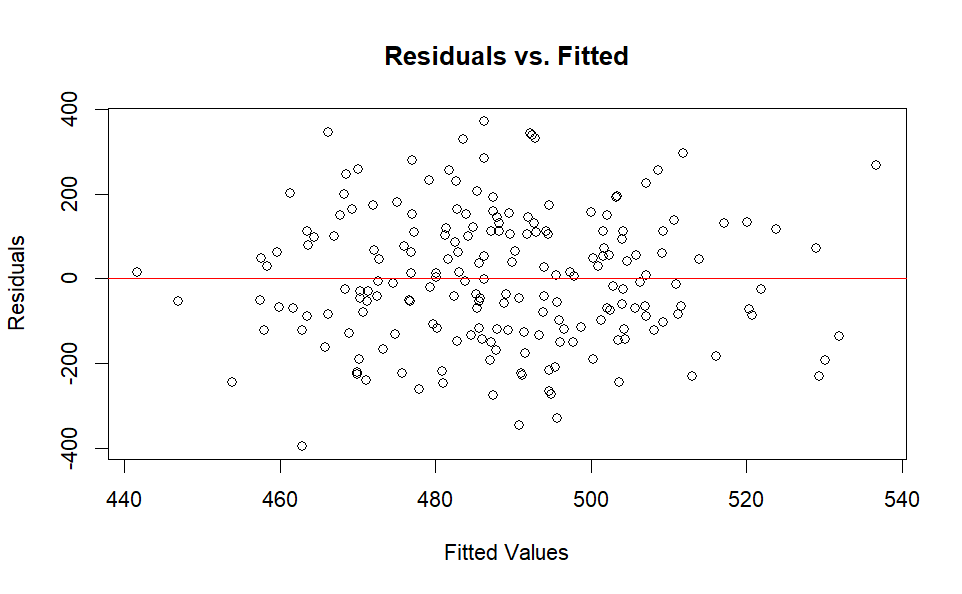

```r
# Residuals vs. Fitted values
plot(inv_model$fitted.values, inv_model$residuals,
     main = "Residuals vs. Fitted", xlab = "Fitted Values", ylab = "Residuals")
abline(h = 0, col = "red")
```

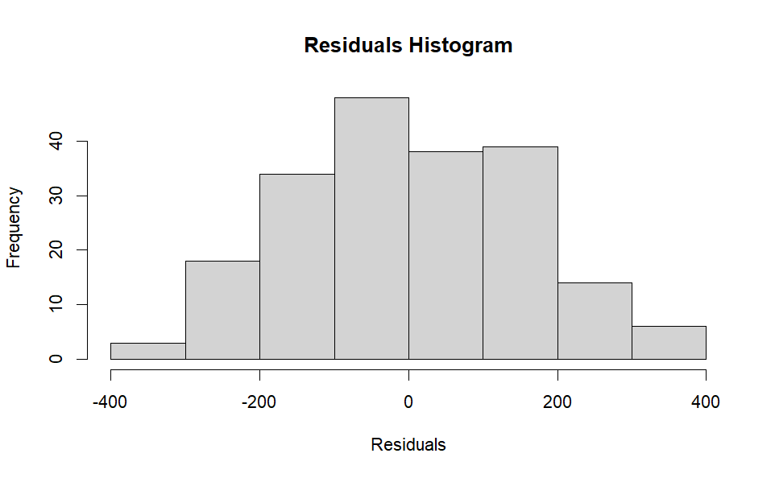

```r
# Histogram of residuals
hist(inv_model$residuals, main = "Residuals Histogram", xlab = "Residuals")
```

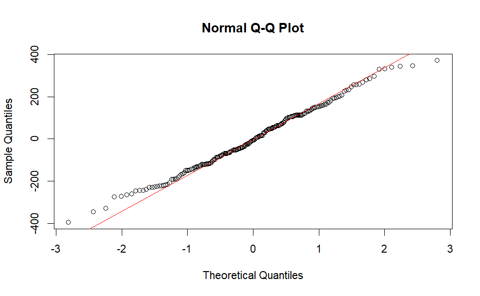

```r
# QQ plot of residuals
qqnorm(inv_model$residuals)
qqline(inv_model$residuals, col = "red")
```

## 2.

**Optimization:**

- Use your model to optimize inventory levels for a peak sales season, balancing minimizing stockouts with minimizing overstock.

Assuming where not going to use the Seasonality Metric in the data set, our goal is to ensure we have enough in, or do not run out of stock.

```r
# Define sales increase scenarios (10%, 30%, and 50%)
sales_scenarios <- c(1.1, 1.3, 1.5)  # Multipliers for increase

inventory_scenarios <- lapply(sales_scenarios, function(increase) {
  peak_sales <- mean(retail_df$Sales) * increase
  peak_inputs <- data.frame(
    Sales = peak_sales,
    Lead_Time_Days = mean(retail_df$Lead_Time_Days),
    Price = mean(retail_df$Price)
  )
  predicted_inventory <- predict(inv_model, newdata = peak_inputs)
  safety_stock <- 1.645 * sd(retail_df$Sales) * sqrt(mean(retail_df$Lead_Time_Days))
  optimal_inventory <- predicted_inventory + safety_stock
  return(optimal_inventory)
})

# Name the scenarios for easy reference
names(inventory_scenarios) <- c("10% Increase", "30% Increase", "50% Increase")
inventory_scenarios
```

```
$`10% Increase`
       1
2481.301

$`30% Increase`
       1
2480.307

$`50% Increase`
       1
2479.312
```

As a result of reviewing the inventory results at a spike of these levels, we see that the predicted inventory units needed are very close. Although not intentional, it does support having a stock close to 2480 units, for expected peak times.

# Referenced sites.

1. [Statology fitdistr-r](https://www.statology.org/fitdistr-r/)
2. [rdocumentation MASS package fitdistr](https://www.rdocumentation.org/packages/MASS/versions/7.3-61/topics/fitdistr)
3. [Statology - fit gamma distribution to dataset in r](https://www.statology.org/fit-gamma-distribution-to-dataset-in-r/)
4. [Wiki Gamma Distribution](https://en.wikipedia.org/wiki/Gamma_distribution)
5. [rdocumentation qualtile](https://www.rdocumentation.org/packages/stats/versions/3.6.2/topics/quantile)
6. [statlect lognormal distribution](https://www.statlect.com/probability-distributions/log-normal-distribution)
7. [Penn State University Online Stat 200 book](https://online.stat.psu.edu/stat200/book/export/html/124)
8. [Geeks for Geeks: simple linear regression using r](https://www.geeksforgeeks.org/simple-linear-regression-using-r/)
9. [Yes I reference Reddit please do not judge](https://www.reddit.com/r/AskStatistics/comments/1dfoa4l/fishers_exact_vs_chisquare/)
10. [LU Decomposition of Square Matrix](https://www.rdocumentation.org/packages/matrixcalc/versions/1.0-6/topics/lu.decomposition)
11. [Three simple matrix decompositions](https://tomroth.dev/decomp/)
12. LU Decomposition Method for Solving Simultaneous Linear Equations.
13. [Geeks for Geeks LU decomposition linear equations](https://www.geeksforgeeks.org/l-u-decomposition-system-linear-equations/#)